# Aggregate to Target-Level Data

The previous notebook, *Disaggregated Data Exploration and ICC Computation*, looked through the disaggregated data, computed the ICCs, and made some additional exclusions (we kicked out cases where participants said they knew the target). Here, I aggregate up to target-level data, which is what we’ll use for the focal analyses.

```r
head(df)
```

| pID | target_user | stim | study | sam | df | start_date | end_date | finished | consent | sample | same_target | duration | survey_sd | attempt | stim_attempt | mult_attempts | mult_stim_attempts | know | qlabel | value |
| --- | --- | --- | --- | --- | --- | --- | --- | --- | --- | --- | --- | --- | --- | --- | --- | --- | --- | --- | --- | --- |
| 201 | 92 | profile | 1 | 1 | 1 | 2013-10-12 16:25:12 | 2013-10-12 16:46:35 | 1 | 1 | hsp | 0 | 21.38333 | 3.742554 | 1 | 1 | 0 | 0 | 2 | actimag | 3 |
| 201 | 92 | profile | 1 | 1 | 1 | 2013-10-12 16:25:12 | 2013-10-12 16:46:35 | 1 | 1 | hsp | 0 | 21.38333 | 3.742554 | 1 | 1 | 0 | 0 | 2 | age | 19 |
| 201 | 92 | profile | 1 | 1 | 1 | 2013-10-12 16:25:12 | 2013-10-12 16:46:35 | 1 | 1 | hsp | 0 | 21.38333 | 3.742554 | 1 | 1 | 0 | 0 | 2 | arrogant | 3 |
| 201 | 92 | profile | 1 | 1 | 1 | 2013-10-12 16:25:12 | 2013-10-12 16:46:35 | 1 | 1 | hsp | 0 | 21.38333 | 3.742554 | 1 | 1 | 0 | 0 | 2 | assertive | 4 |
| 201 | 92 | profile | 1 | 1 | 1 | 2013-10-12 16:25:12 | 2013-10-12 16:46:35 | 1 | 1 | hsp | 0 | 21.38333 | 3.742554 | 1 | 1 | 0 | 0 | 2 | attractive | 3 |
| 201 | 92 | profile | 1 | 1 | 1 | 2013-10-12 16:25:12 | 2013-10-12 16:46:35 | 1 | 1 | hsp | 0 | 21.38333 | 3.742554 | 1 | 1 | 0 | 0 | 2 | centerattn | 4 |

I’m starting with a very long (each row is 1 response) df that has the data for each study and stimulus. This data set has been filtered to only include responses for unknown targets, the first attempt of each stimuli (for study 1), and has excluded subsequent attempts that rated the same targets. For sanity, let’s just be sure that’s all true.

```r
summary(as.factor(df$stim_attempt))
```

```
     1
119790
```

```r
summary(as.factor(df$mult_stim_attempts))
```

```
     0      1
116594   3196
```

```r
summary(as.factor(df$know))
```

```
     2
119790
```

```r
summary(as.factor(df$consent))
```

```
     1
119790
```

```r
summary(as.factor(df$same_target))
```

```
     0      1
119280    510
```

Cool cool. Let’s get down to business. (That 1 for same_target is for the first attempt from the participants who saw the same target - nothing to worry about there.)

## Target-level aggregation

To get the scores for each target, we need to take the average rating for each question (except for sex and race) across all percievers who saw that target with that stimulus.

```r
unique(df$qlabel)
```

```
 [1] "actimag"                "age"                    "arrogant"               "assertive"
 [5] "attractive"             "centerattn"             "cold"                   "fewartint"
 [9] "funny"                  "ilike"                  "impulsive"              "intelligent"
[13] "lazy"                   "nervous"                "outgoing"               "race"
[17] "relaxed"                "reserved"               "selfesteem"             "ses"
[21] "sex"                    "thorough"               "trusting"               "trustworthy"
[25] "cold_r"                 "reserved_r"             "lazy_r"                 "relaxed_r"
[29] "fewartint_r"            "ext"                    "agr"                    "con"
[33] "neu"                    "ope"                    "adviceGoodImpression"   "askNotes"
[37] "buySomethingOnline"     "casualSocial"           "converseIntellStim"     "followSM"
[41] "friendshipOnline"       "friendsOffline"         "groupProject"           "helpConflict"
[45] "helpIntellChallenge"    "hire"                   "interestNewsOnline"     "introduceFriend"
[49] "movieTVrec"             "musicRec"               "paperFeedback"          "romanticPartner_friend"
[53] "romanticPartner_self"   "triviaPartner"          "trustDeadlines"         "trustInfoOnline"
[57] "trustOrganize"          "valueOpinion"           "workStressfulTask"      "workTaskConflict"
```

```r
target_scores <- df[which(df$qlabel != 'sex' & df$qlabel != 'race'),] %>%
                    group_by(study, stim, target_user, qlabel) %>%
                    summarize(targ_agg = mean(value, na.rm = T))
head(target_scores)
```

| study | stim | target_user | qlabel | targ_agg |
| --- | --- | --- | --- | --- |
| 1 | followers | 2 | actimag | 3.40 |
| 1 | followers | 2 | age | 19.40 |
| 1 | followers | 2 | agr | 3.75 |
| 1 | followers | 2 | arrogant | 3.20 |
| 1 | followers | 2 | assertive | 3.30 |
| 1 | followers | 2 | attractive | 3.70 |

### Sex and Race

Since sex and race are (as assessed here) categorical, I’ll use a different strategy to aggregate them. Agreement for both is quite high across perceivers when they see the target’s profile:

```r
ICC <- read_csv('Personality_Impressions_on_Twitter_ICCs_091717.csv')
ICC <- ICC %>% select(-X1)
```

```r
ICC %>% filter((qlabel == 'sex') | (qlabel == 'race'))
```

| study | stim | qlabel | ICC.t_unknown | ICC.p_unknown |
| --- | --- | --- | --- | --- |
| 1 | followers | race | 0.637 | 0.040 |
| 1 | followers | sex | 0.190 | 0.005 |
| 1 | friends | race | 0.673 | 0.019 |
| 1 | friends | sex | 0.214 | 0.000 |
| 1 | profile | race | 0.723 | 0.019 |
| 1 | profile | sex | 0.836 | 0.007 |

I’m also generating a variable that indicates whether percievers achieved > 2/3 majority agreement, in the even that we decide to be more stringent on this in the future.

```r
# function to compute mode
Mode<-function(x){
       ux<-unique(x)
      ux[which.max(tabulate(match(x,ux)))]
}
sexrace <- df[which(df$qlabel == 'sex' | df$qlabel == 'race'),] %>%
                    group_by(study, stim, target_user, qlabel) %>%
                    summarize(targ_agg = Mode(value))
head(sexrace)
```

| study | stim | target_user | qlabel | targ_agg |
| --- | --- | --- | --- | --- |
| 1 | followers | 2 | race | 6 |
| 1 | followers | 2 | sex | 2 |
| 1 | followers | 3 | race | 6 |
| 1 | followers | 3 | sex | 2 |
| 1 | followers | 4 | race | 6 |
| 1 | followers | 4 | sex | 1 |

```r
# get n perc / target
sexrace <- merge(sexrace, df %>% group_by(study, stim, target_user) %>% summarize(nperc = n_distinct(pID)))

# n percievers who gave modal response
tmp <- df %>% filter(qlabel == 'race' | qlabel == 'sex')
tmp <- left_join(tmp, sexrace, by = c('study','stim','target_user','qlabel'))
tmp <- tmp %>% mutate('mode_agree' = as.numeric(value == targ_agg))
tmp <- tmp %>% group_by(study, stim, target_user, qlabel) %>% summarize(sum_mode_agree = sum(mode_agree))

sexrace <- merge(sexrace, tmp)

# sanity check (should be 0 rows)
sexrace %>% filter(sum_mode_agree > nperc)
```

```r
# compute agreement as a percentage
sexrace <- sexrace %>% mutate(pct_agree = sum_mode_agree/nperc)
# indicate where agreement is greater than 50%, 66%
sexrace <- sexrace %>% mutate(pct_agree50 = as.numeric(pct_agree > .5),
                              pct_agree66 = as.numeric(pct_agree > .66))
head(sexrace)
```

|  | study | stim | target_user | qlabel | targ_agg | sum_mode_agree | nperc | pct_agree | pct_agree50 | pct_agree66 |
| --- | --- | --- | --- | --- | --- | --- | --- | --- | --- | --- |
| 1 | 1 | followers | 10 | race | 6 | 9 | 10 | 0.9 | 1 | 1 |
| 2 | 1 | followers | 10 | sex | 2 | 7 | 10 | 0.7 | 1 | 1 |
| 3 | 1 | followers | 100 | race | 3 | 5 | 10 | 0.5 | 0 | 0 |
| 4 | 1 | followers | 100 | sex | 2 | 6 | 10 | 0.6 | 1 | 0 |
| 5 | 1 | followers | 101 | race | 3 | 5 | 10 | 0.5 | 0 | 0 |
| 6 | 1 | followers | 101 | sex | 2 | 9 | 10 | 0.9 | 1 | 1 |

```r
table(sexrace %>% group_by(study, stim, qlabel) %>% select(pct_agree50))
```

```
, , qlabel = race, pct_agree50 = 0

     stim
study followers friends profile
    1         9       6       9

, , qlabel = sex, pct_agree50 = 0

     stim
study followers friends profile
    1         7       3       0

, , qlabel = race, pct_agree50 = 1

     stim
study followers friends profile
    1        91      94      91

, , qlabel = sex, pct_agree50 = 1

     stim
study followers friends profile
    1        93      97     100
```

```r
table(sexrace %>% group_by(study, stim, qlabel) %>% select(pct_agree66))
```

```
, , qlabel = race, pct_agree66 = 0

     stim
study followers friends profile
    1        18      13      19

, , qlabel = sex, pct_agree66 = 0

     stim
study followers friends profile
    1        37      32       1

, , qlabel = race, pct_agree66 = 1

     stim
study followers friends profile
    1        82      87      81

, , qlabel = sex, pct_agree66 = 1

     stim
study followers friends profile
    1        63      68      99
```

Generally, agreement looks pretty good. For the folks where agreement on race is below 50%, I’ll recode them into a separate category. Where agreement is below 50% for sex (only true for friends/followers), we’ll stick with the mode.

[output not shown]

Add back to target scores:

```r
target_scores <- bind_rows(target_scores, sexrace[,1:5])
head(target_scores)
```

| study | stim | target_user | qlabel | targ_agg |
| --- | --- | --- | --- | --- |
| 1 | followers | 2 | actimag | 3.40 |
| 1 | followers | 2 | age | 19.40 |
| 1 | followers | 2 | agr | 3.75 |
| 1 | followers | 2 | arrogant | 3.20 |
| 1 | followers | 2 | assertive | 3.30 |
| 1 | followers | 2 | attractive | 3.70 |

```r
summary(as.factor(target_scores$qlabel))
```

```
               actimag   adviceGoodImpression                    age                    agr
                   300                    100                    300                    300
              arrogant               askNotes              assertive             attractive
                   300                    100                    300                    300
    buySomethingOnline           casualSocial             centerattn                   cold
                   100                    100                    300                    300
                cold_r                    con     converseIntellStim                    ext
                   300                    300                    100                    298
             fewartint            fewartint_r               followSM       friendshipOnline
                   300                    300                    100                    100
        friendsOffline                  funny           groupProject           helpConflict
                   100                    300                    100                    100
   helpIntellChallenge                   hire                  ilike              impulsive
                   100                    100                    300                    300
           intelligent     interestNewsOnline        introduceFriend                   lazy
                   300                    100                    100                    300
                lazy_r             movieTVrec               musicRec                nervous
                   300                    100                    100                    300
                   neu                    ope               outgoing          paperFeedback
                   300                    300                    298                    100
                  race                relaxed              relaxed_r               reserved
                   300                    300                    300                    300
            reserved_r romanticPartner_friend   romanticPartner_self             selfesteem
                   300                    100                    100                    300
                   ses                    sex               thorough          triviaPartner
                   300                    300                    300                    100
        trustDeadlines        trustInfoOnline               trusting          trustOrganize
                   100                    100                    300                    100
           trustworthy           valueOpinion      workStressfulTask       workTaskConflict
                   300                    100                    100                    100
```

```r
unique(target_scores$qlabel)
```

```
 [1] "actimag"                "age"                    "agr"                    "arrogant"
 [5] "assertive"              "attractive"             "centerattn"             "cold"
 [9] "cold_r"                 "con"                    "ext"                    "fewartint"
[13] "fewartint_r"            "funny"                  "ilike"                  "impulsive"
[17] "intelligent"            "lazy"                   "lazy_r"                 "nervous"
[21] "neu"                    "ope"                    "outgoing"               "relaxed"
[25] "relaxed_r"              "reserved"               "reserved_r"             "selfesteem"
[29] "ses"                    "thorough"               "trusting"               "trustworthy"
[33] "adviceGoodImpression"   "askNotes"               "buySomethingOnline"     "casualSocial"
[37] "converseIntellStim"     "followSM"               "friendshipOnline"       "friendsOffline"
[41] "groupProject"           "helpConflict"           "helpIntellChallenge"    "hire"
[45] "interestNewsOnline"     "introduceFriend"        "movieTVrec"             "musicRec"
[49] "paperFeedback"          "romanticPartner_friend" "romanticPartner_self"   "triviaPartner"
[53] "trustDeadlines"         "trustInfoOnline"        "trustOrganize"          "valueOpinion"
[57] "workStressfulTask"      "workTaskConflict"       "race"                   "sex"
```

## Study 2 Decisions

We know from previous exploration of the Study 2 data that there’s a strong evaluative factor – percievers either wanted to interact with targets or they didn’t. I’ll verify that here, and then proceed with ipsatizing (i.e., removing the mean across all scores) the responses.

#### PCA:

```r
s2df<-dcast(target_scores %>% filter(study == 2),
                target_user
               ~qlabel,
               value.var="targ_agg")
s2df <- s2df %>% select(-target_user)
```

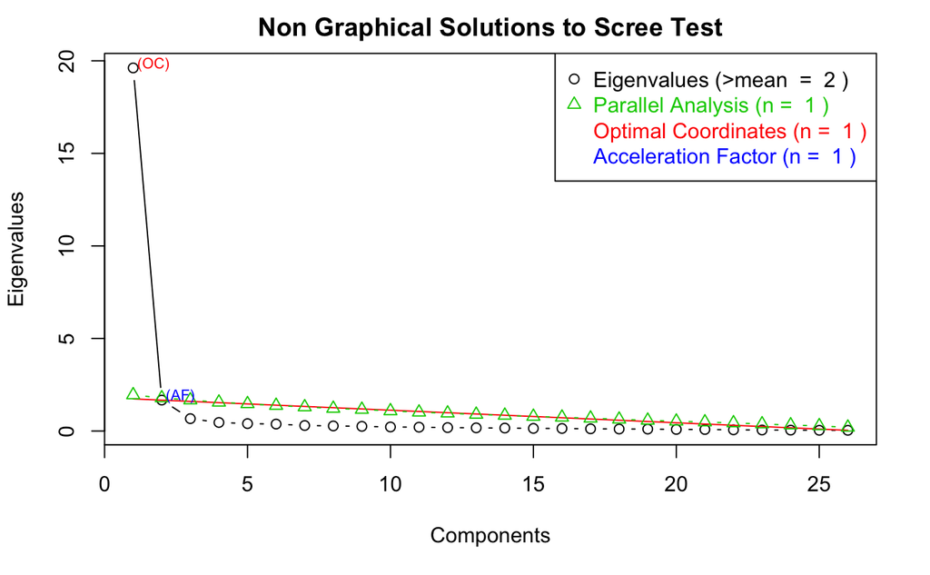

```r
library(nFactors)
ev <- eigen(cor(s2df)) # get eigenvalues
ap <- parallel(subject=nrow(s2df),var=ncol(s2df),rep=100,cent=.05)
nS <- nScree(x=ev$values, aparallel=ap$eigen$qevpea)
plotnScree(nS)
```

```r
fit <- psych::principal(s2df, rotate="varimax")
fit
```

```
Principal Components Analysis
Call: psych::principal(r = s2df, rotate = "varimax")
Standardized loadings (pattern matrix) based upon correlation matrix
                        PC1   h2   u2 com
adviceGoodImpression   0.92 0.85 0.15   1
askNotes               0.91 0.82 0.18   1
buySomethingOnline     0.83 0.69 0.31   1
casualSocial           0.87 0.76 0.24   1
converseIntellStim     0.90 0.81 0.19   1
followSM               0.77 0.60 0.40   1
friendshipOnline       0.88 0.78 0.22   1
friendsOffline         0.89 0.80 0.20   1
groupProject           0.94 0.88 0.12   1
helpConflict           0.91 0.82 0.18   1
helpIntellChallenge    0.91 0.84 0.16   1
hire                   0.90 0.80 0.20   1
interestNewsOnline     0.86 0.73 0.27   1
introduceFriend        0.88 0.77 0.23   1
movieTVrec             0.71 0.50 0.50   1
musicRec               0.65 0.42 0.58   1
paperFeedback          0.92 0.85 0.15   1
romanticPartner_friend 0.82 0.67 0.33   1
romanticPartner_self   0.73 0.54 0.46   1
triviaPartner          0.86 0.73 0.27   1
trustDeadlines         0.91 0.82 0.18   1
trustInfoOnline        0.92 0.85 0.15   1
trustOrganize          0.89 0.80 0.20   1
valueOpinion           0.87 0.76 0.24   1
workStressfulTask      0.95 0.89 0.11   1
workTaskConflict       0.91 0.83 0.17   1

                 PC1
SS loadings    19.62
Proportion Var  0.75

Mean item complexity =  1
Test of the hypothesis that 1 component is sufficient.

The root mean square of the residuals (RMSR) is  0.06
 with the empirical chi square  234.82  with prob <  1

Fit based upon off diagonal values = 0.99
```

So, clearly still one factor there. Let’s ipsatize.

```r
target_scores <- left_join(target_scores,
                           target_scores %>% filter(study == 2) %>% summarize(s2m = mean(targ_agg)))
head(target_scores)
```

| study | stim | target_user | qlabel | targ_agg | s2m |
| --- | --- | --- | --- | --- | --- |
| 1 | followers | 2 | actimag | 3.40 | NA |
| 1 | followers | 2 | age | 19.40 | NA |
| 1 | followers | 2 | agr | 3.75 | NA |
| 1 | followers | 2 | arrogant | 3.20 | NA |
| 1 | followers | 2 | assertive | 3.30 | NA |
| 1 | followers | 2 | attractive | 3.70 | NA |

[output not shown]

[output not shown]

Great. So targ_agg is the original aggregate, and targ_agg2 has the ipstized values. For study 1, targ_agg == targ_agg2.